# Time Series Analysis - Dow Jones Industrial

Siyuan Zheng

April 6th, 2017

# Data Description

- The data is the monthly excess return of Dow Jones Industrial Average from January 2005 to February 2017
- Where monthly excess return is defined as $\frac{Close\:price\:of\:the\:month\:−\:Open\:price\:of\:the\:month}{Open\:price\:of\:the\:month}$
- Historical data is downloaded from http://finance.yahoo.com

```r
#The following commands have been run in the console to install relevant packages
#install.packages("dygraphs")
#install.packages("ltsa")
#install.packages("forecast")
#install.packages("tseries")
#install.packages("entropy")
#install.packages("arfima")
#install.packages("ggplot2")
#install.packages("ggfortify")
#install.packages("gamlss")
#import the libraries
library(dygraphs)
library(forecast)
library(ltsa)
library(tseries)
library(entropy)
library(arfima)
library(ltsa)
# Data entry in the csv files have been adjusted to date-ascending order
data <-read.csv("table.csv", header=TRUE)
# What does the data look like ?
head(data)
```

```
##       Date     Open     High      Low    Close    Volume Adj.Close
## 1 05-01-03 10783.75 10867.39 10368.61 10489.94 286149500  10489.94
## 2 05-02-01 10489.72 10853.43 10489.64 10766.23 280355700  10766.23
## 3 05-03-01 10769.04 10984.46 10396.24 10503.76 276336800  10503.76
## 4 05-04-01 10504.57 10568.93 10000.46 10192.51 293144200  10192.51
## 5 05-05-02 10192.00 10560.81 10075.55 10467.48 242084700  10467.48
## 6 05-06-01 10462.86 10656.29 10253.49 10274.97 242206300  10274.97
```

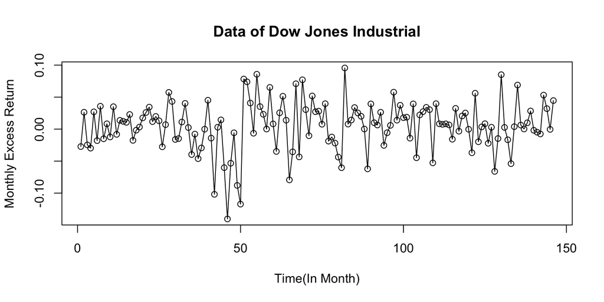

```r
# As required, defined the data of monthly excess return as (Close-Open)/Open
DJI = ts((data$Close-data$Open)/data$Open)
# The plot of the historical data
plot(DJI,main="Data of Dow Jones Industrial", xlab="Time(In Month)",ylab="Monthly Excess Return",type="o")
```

```r
# Making the TS plot interactive
dygraph(DJI)
```

[interactive chart not shown]

# Time Series Modelling

```r
# To see whether the data need transformation
lambda <- BoxCox.lambda(DJI)
lambda
```

```
## [1] 0.894564
```

```r
# plot(stl(DJI)), this causes the halt of the program, which says there is no periodic component, thus ignoring the procedure of decomposition(removing trend and seasonal)
```

#### Since lambda is very cloes to 1, we do not need to make transformation to the data

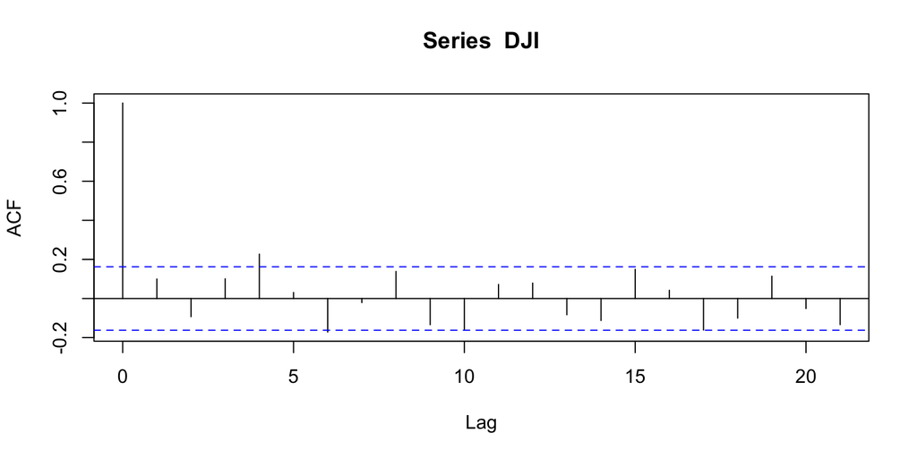

```r
# since acf of MA model is cut-off, used to determine the candidate of p
acf(DJI)
```

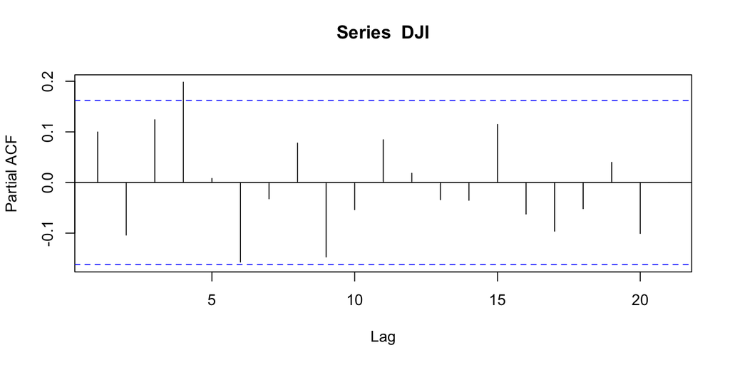

```r
# since pacf of AR model is cut-off, used to determine the candidate of q
pacf(DJI)
```